# alpha and segmentation analysis

Savannah C.

18 November, 2019

## uCLIMB subjects results

### Description of Segmentation data

#### raster plots

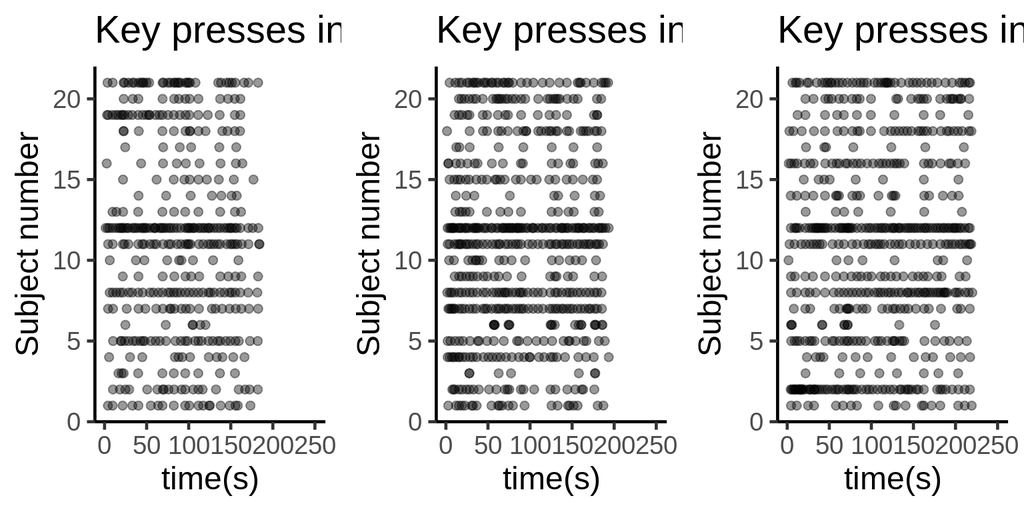

```r
fig.v3 <- subject.keyPresses.v3 %>% melt() %>% ggplot(aes(value, L1)) + geom_point(size=2, alpha=0.4)+#(shape=3, size=2) +
  xlab('time(s)') + ylab('Subject number') +
  theme_classic(base_size = 18) + xlim(c(1,250)) +
  labs(title='Key presses in Video 3(v7)')

fig.v2 <-subject.keyPresses.v2 %>% melt() %>% ggplot(aes(value, L1)) + geom_point(size=2, alpha=0.4)+#(shape=3, size=2) +
  xlab('time(s)') + ylab('Subject number') +
  theme_classic(base_size = 18) + xlim(c(1,250)) +
  labs(title='Key presses in Video 2(v5)')

fig.v1 <- subject.keyPresses.v1 %>% melt() %>% ggplot(aes(value, L1)) + geom_point(size=2, alpha=0.4)+#(shape=3, size=2) +
  xlab('time(s)') + ylab('Subject number') +
  theme_classic(base_size = 18) + xlim(c(1,250)) +
  labs(title='Key presses in Video 1(v1)')

grid.arrange(fig.v1,fig.v2,fig.v3, nrow = 1, ncol = 3)
```

- Video 1: the ratio of normal segmenters to outlying segmenters is 4.25.
- Video 2: the ratio of normal segmenters to outlying segmenters is 2.5.
- Video 3: the ratio of normal segmenters to outlying segmenters is 4.25.
- A ratio of 3.5 across all videos.

**Jafarpour’s ratio is 1.5714286 across videos** This suggests that our data is not represetative of what the typical space of segmentation performance is when compared to Jaffarpour’s data. But this may be due to differences in data collection: participants viewed videos only once in our experiment.

The first and third videos have an overarching storyline while the second video does not. Participants segmented movie 1 the most in Jafarpour’s study at 13.45 events (SD = 8.86), while movie 2 was segmented into 9.78 events (SD = 5.8), and movie 3 into 11.27 events (SD = 8.01). We predicted our participants will similarly segment movie 1 the most, followed by movie 3 and movie 2, respectively. This is very different from the data we collected (see summary table below). We suspect that this may be because our participants viewed the videos only once during segmentation.

|  | n | mean | sd | min | max | range | se |
| --- | --- | --- | --- | --- | --- | --- | --- |
| V.1 | 21 | 20.57143 | 14.14062 | 7 | 64 | 57 | 3.085736 |
| V.2 | 21 | 28.42857 | 16.82430 | 8 | 81 | 73 | 3.671364 |
| V.3 | 21 | 28.23810 | 19.65936 | 8 | 79 | 71 | 4.290024 |

Consistency of segmenter behavior across videos:

Jafarpour’s correlations were:

- movie 1 vs movie 2: r = 0.85, p < 0.001
- movie 2 vs movie 3: r = 0.86, p < 0.001
- movie 1 vs movie 3: r = 0.71, p < 0.001

Table of correlations using the spearman ranked test:

```r
segmenter.cons <- corr.test(segment.dat[,2:4], method = 'spearman', adjust = 'holm')
segmenter.cons$r %>% as.data.frame() %>% kable(.)
```

|  | V.1 | V.2 | V.3 |
| --- | --- | --- | --- |
| V.1 | 1.0000000 | 0.7820555 | 0.7308079 |
| V.2 | 0.7820555 | 1.0000000 | 0.7006542 |
| V.3 | 0.7308079 | 0.7006542 | 1.0000000 |

Table of p-values:

|  | V.1 | V.2 | V.3 |
| --- | --- | --- | --- |
| V.1 | 0.00e+00 | 8.44e-05 | 0.0003361 |
| V.2 | 2.81e-05 | 0.00e+00 | 0.0004040 |
| V.3 | 1.68e-04 | 4.04e-04 | 0.0000000 |

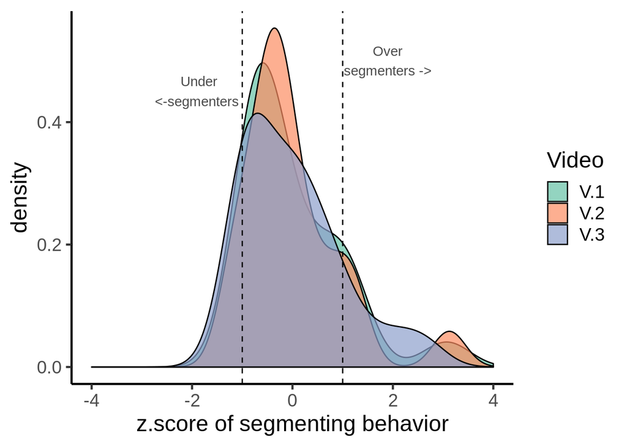

There is a lot of skew in these data: we’ll be using nonparametric tests (Wilcoxon Ranked-sum test, Spearman correlation etc).

For our planned analyses, we’re assuming no difference between videos and taking the sum of number of segments to categorize subjects in to normative segmenters and atypical segmenters. Thoughts?

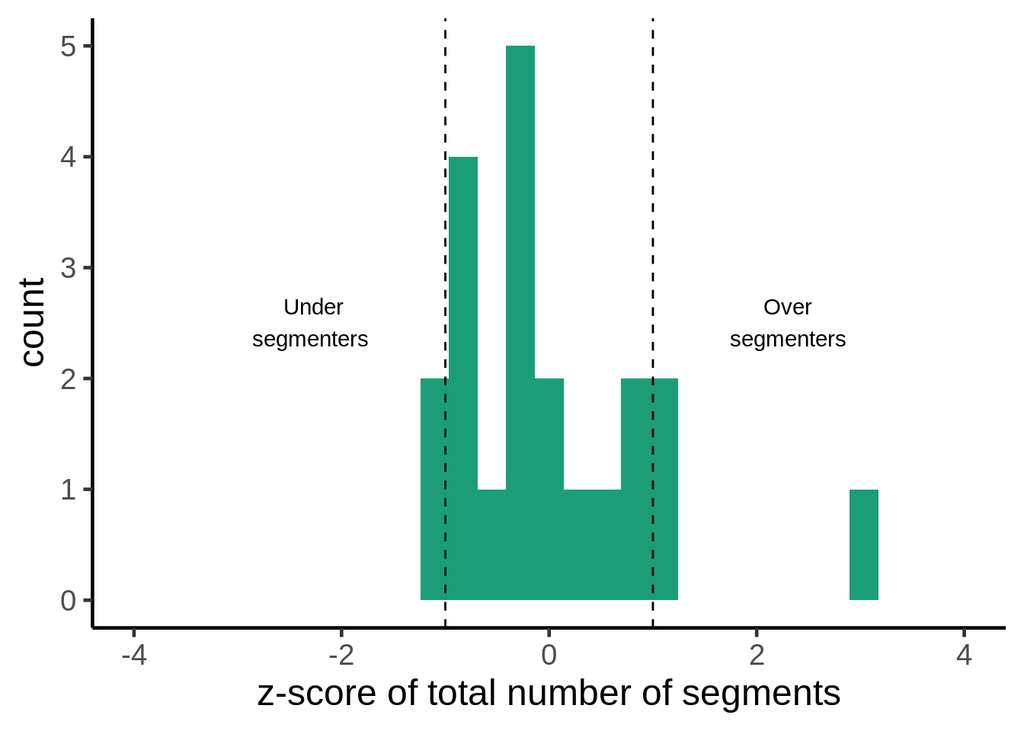

Most of our participants fall in the *normative segmenter* group with very few over and under segmenters.

### Part 1: How do the psychometric measures relate to eachother? Do they reflect our expectations as dictated by literature?

Note: Composite working memory score was computed by averaging Symmetry span, Operation span and Reading span tasks.

|  | n | mean | sd | min | max | range | se |
| --- | --- | --- | --- | --- | --- | --- | --- |
| Ravens.Score | 21 | 12.952381 | 2.836833 | 8 | 18.00000 | 10.00000 | 0.6190476 |
| SspanAbsoluteScore | 21 | 6.904762 | 3.645611 | 0 | 14.00000 | 14.00000 | 0.7955374 |
| RspanScore | 21 | 22.523809 | 4.490201 | 13 | 30.00000 | 17.00000 | 0.9798422 |
| OspanAbsoluteScore | 21 | 15.380952 | 5.869209 | 3 | 25.00000 | 22.00000 | 1.2807665 |
| compositeWM | 21 | 14.936508 | 3.564671 | 7 | 21.33333 | 14.33333 | 0.7778750 |

Density plots of z-scored Ravens and Working memory measures:

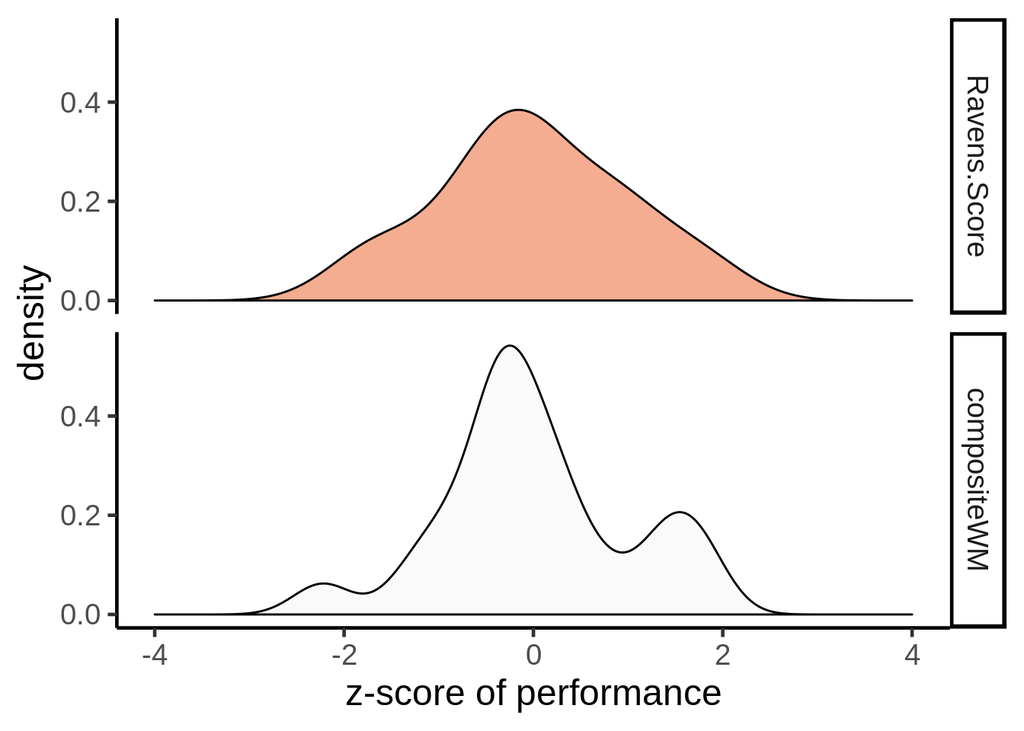

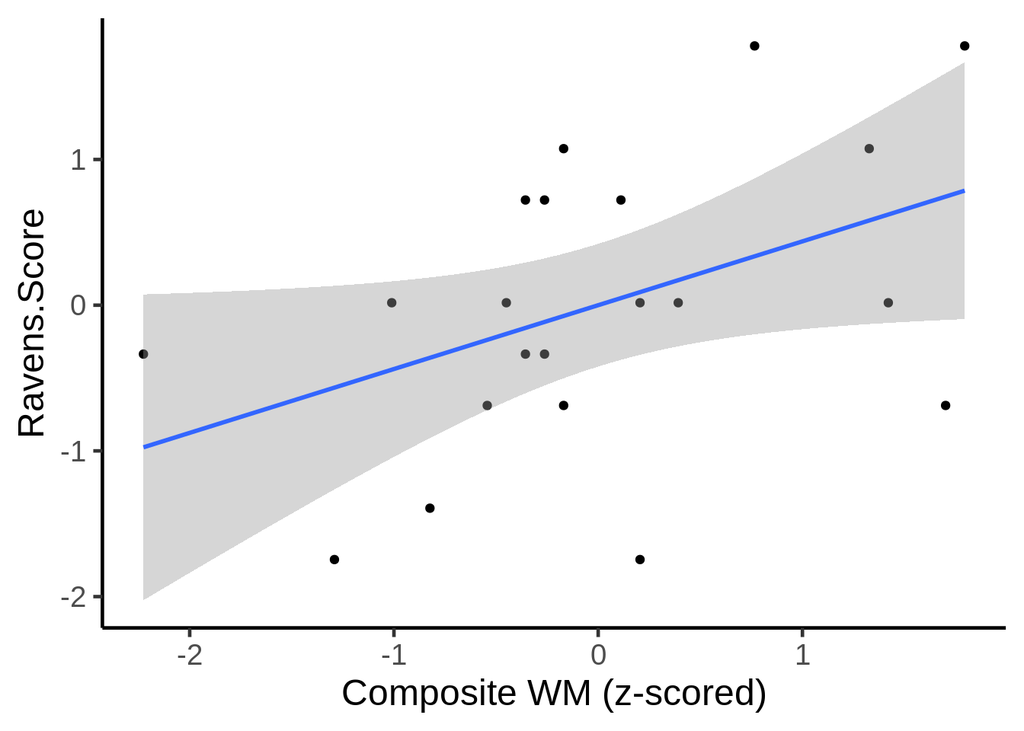

```r
cbind(uclimb.psychometrics, tot.seg=rowSums(segment.dat[,2:4]) )%>%
  scale() %>% as.data.frame() %>%
  ggplot(aes(compositeWM,Ravens.Score)) +
  geom_point() + geom_smooth(method = 'lm') +
  xlab('Composite WM (z-scored)')+
 #geom_tile(('Correlation of total segmentation vs ravens score') ) +
  theme_classic(base_size = 18 )
```

We would expect that normative segmenters would have higher raven’s score because normal segmentation predicts better memory performance (and Raven’s and Working memory are closely related).

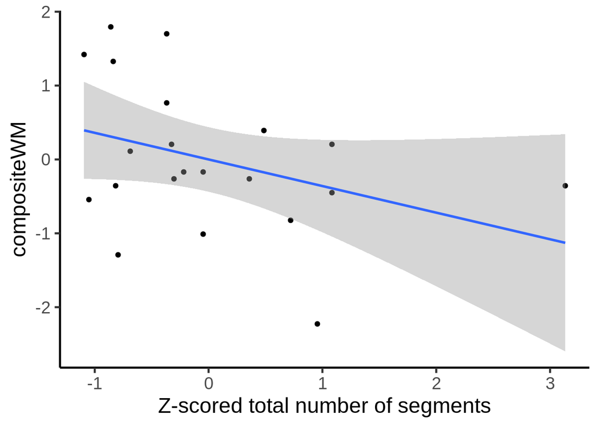

Table of correlation values:

```r
ravens.wm.seg <- cbind(uclimb.psychometrics[,c(1,5)], total.segments=rowSums(segment.dat[,2:4]) )%>%
   corr.test(., method = 'spearman', adjust = 'holm')

  ravens.wm.seg$r %>% as.data.frame() %>% kable(.)
```

|  | Ravens.Score | compositeWM | total.segments |
| --- | --- | --- | --- |
| Ravens.Score | 1.0000000 | 0.4327749 | -0.1683196 |
| compositeWM | 0.4327749 | 1.0000000 | -0.3865929 |
| total.segments | -0.1683196 | -0.3865929 | 1.0000000 |

Table of p-values for correlations above:

```r
 ravens.wm.seg$p %>% as.data.frame() %>% kable(.)
```

|  | Ravens.Score | compositeWM | total.segments |
| --- | --- | --- | --- |
| Ravens.Score | 0.0000000 | 0.1501460 | 0.4657970 |
| compositeWM | 0.0500487 | 0.0000000 | 0.1668476 |
| total.segments | 0.4657970 | 0.0834238 | 0.0000000 |

### Part 2: Does alpha frequency relate to segmentation?

#### Alpha frequency:

Alpha frequency is traditionally measured between 7.5 and 12.5 Hz. Young adults in their 20’s have an average IAF (individual alpha frequency, frequency of the peak) of 10.89 Hz with a typical range between 9.5 and 11.5 Hz. EEG detects the most pronounced alpha frequency levels in the occipital region. Therefore, we plan to primarily focus on 2 channels, O1 and O2, and assess for IAF and IAF power (the power at peak) at each channel.

Our prediction is that normative segmenters would have higher alpha because this predicts better working memory performance (Klimesch, 1999).

Note: The mean frequencies for the OLCTS and PYTHON groups were used for those instances where there are 2 datapoints

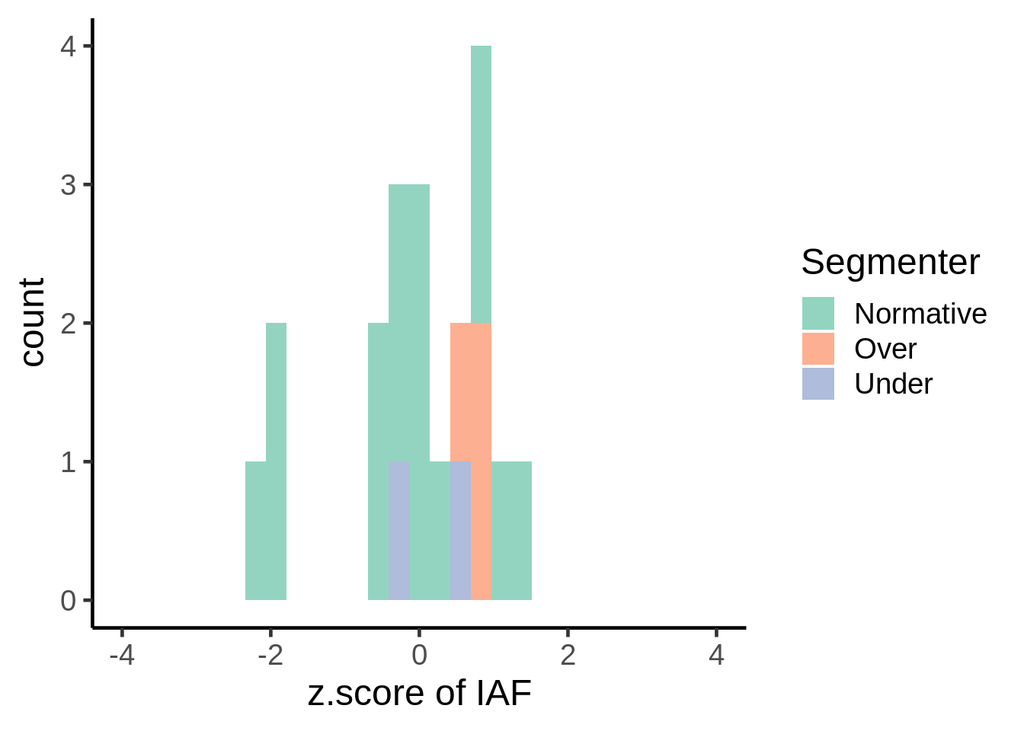

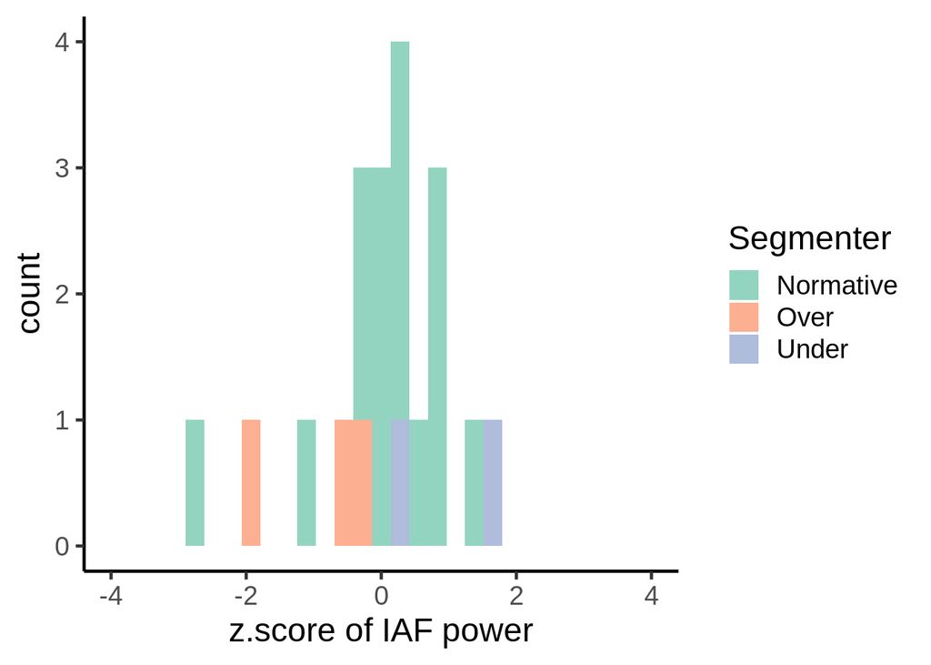

#### Alpha vs working memory and Raven’s

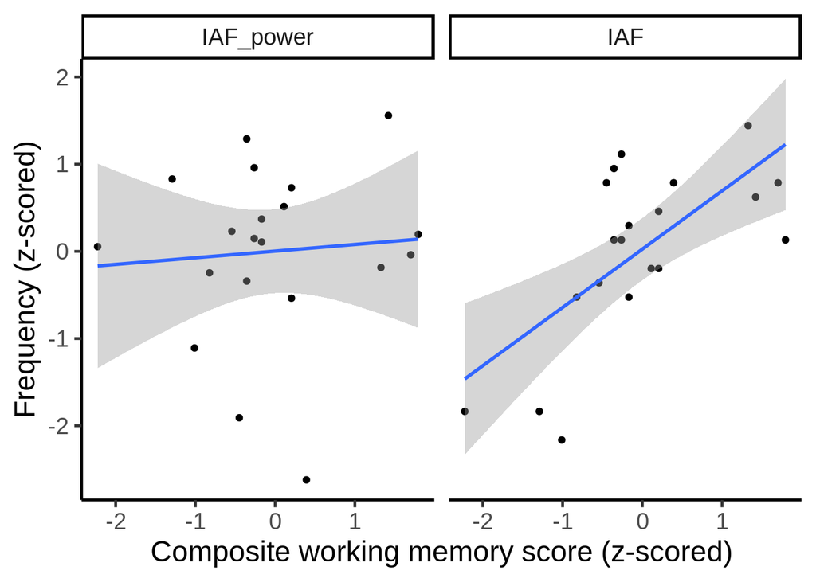

#### Correlation of Alpha with segmentation behavior

We predict that both under segmenters and over segmenters would have lower alpha frequency.

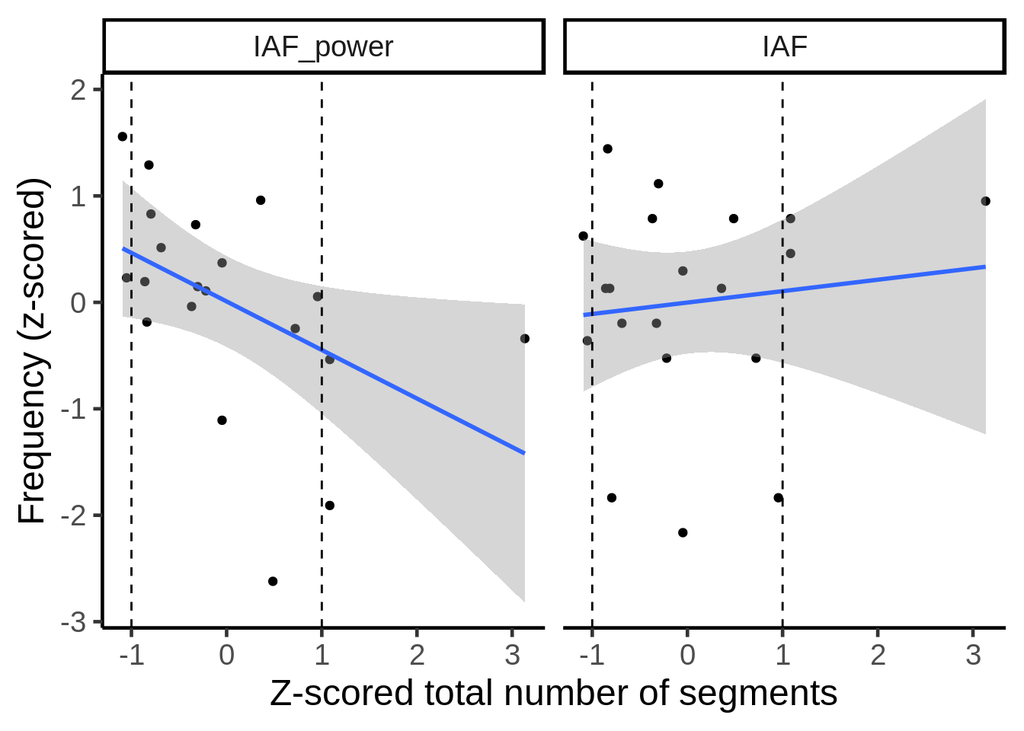

> Correlations and pvalues for the above plot:

```r
alpha_seg_cor <- cbind(IAF_power = rowMeans(alpha_and_seg[, c(6,7)]), IAF = rowMeans(alpha_and_seg[, c(8,9)]),tot.seg=rowSums(alpha_and_seg[, 2:4]))  %>%
  scale() %>% as.data.frame() %>% corr.test(., method = 'spearman', adjust = 'holm')
alpha_seg_cor$r%>%kable()
```

|  | IAF_power | IAF | tot.seg |
| --- | --- | --- | --- |
| IAF_power | 1.0000000 | -0.2257475 | -0.6403313 |
| IAF | -0.2257475 | 1.0000000 | 0.0559127 |
| tot.seg | -0.6403313 | 0.0559127 | 1.0000000 |

```r
alpha_seg_cor$p%>%kable()
```

|  | IAF_power | IAF | tot.seg |
| --- | --- | --- | --- |
| IAF_power | 0.0000000 | 0.6771349 | 0.0070664 |
| IAF | 0.3385674 | 0.0000000 | 0.8148831 |
| tot.seg | 0.0023555 | 0.8148831 | 0.0000000 |

# SAVANNAH THIS HAS CHANGED!

From the data we have, there is *a significant relationship with IAF_power and segmentation* but not with IAF and segmentation. *The relationship was not as we predicted but we are limited by the data we have to draw any conclusions*

### Planned analyses

- does segmentation behavior matter based on which video was viewed first? Do subjects get used to the task and segment less?
- Non-parametric hypothesis test to test group differences of Normative, over and under segmenters in alpha, Raven’s and wm.